# Basics of visualizing phylogenies

Author

Jeet Sukumaran

## 1 Expressing phylogenies as Newick strings

A phylogeny can be expressed as a *Newick string*. That is, a *string* (in the computer science sense of a sequence of characters) in the “Newick” format. The Newick format is named after the lobster restaurant in which the format was sketched out on a napkin. Since its original formulation, there has been a large range of custom, specialized, idiosyncratic, or bespoke variants of Newick developed to accommodate different analysis needs, requirements, and preferences. Here we will go over the broad commonalities supported across most variants, with a ruleset that minimizes compatibility issues across different software implementations.

### 1.1 Phylogenetic trees expressed as Newick strings

A phylogenetic tree topology expressed in Newick format is a string of characters terminated by a semicolon, in which: Nodes are labeled with characters that include the standard alphanumeric characters, commas are used to separate nodes, while parentheses are used to group nodes into clades.

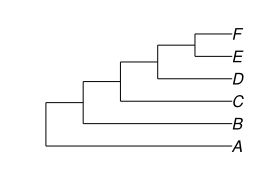

```
(A,(B,(C,(D,(E,F)))));
```

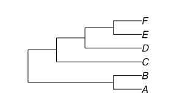

```
((A,B),(C,(D,(E,F))));
```

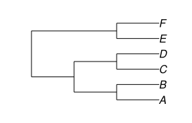

```
(((A,B),(C,D)),(E,F));
```

### 1.2 Internal node labels

Text placed immediately after the closing parenthesis for an internal node assigns a label to that node. The final label names the root node.

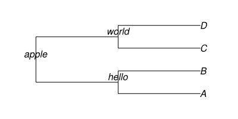

```
((A,B)hello,(C,D)world)apple;
```

### 1.3 Branch lengths

A colon followed by a number records the length of the branch subtending (incoming edge leading to) a node. These values can scale the branches in the visualization and can also be displayed as branch annotations.

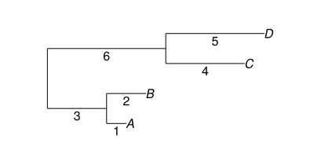

```
((A:1,B:2):3,(C:4,D:5):6):7;
```

### 1.4 Branch lengths and internal node labels

An internal node label follows its closing parenthesis, and the branch length follows that label after a colon.

[figure not shown]

```
((A:1,B:2)hello:3,(C:4,D:5)world:6)said_the_hobbit:7;
```

In general, node labels can be safely composed with alphanumeric characters:

- Lowercase alphabetic characters: `a b c d e f g h i j k l m n o p q r s t u v w x y z`
- Uppercase alphabetic characters: `A B C D E F G H I J K L M N O P Q R S T U V W X Y Z`
- Numerals: `0 1 2 3 4 5 6 7 8 9`

In addition, the following characters are generally supported and can be used to make multipart labels easier to read:

- `.` (period)
- `_` (underscore). Some programs can translate underscores to spaces (so `Agkistrodon_sp` becomes `Agkistrodon sp`), as dictated by the original Newick standard, while others ignore this stipulation.

**WarningNewick-reserved characters**

In contrast, the following characters are used by the Newick format itself and will break parsers if they are used in unquoted labels:

- `-` (hyphen or dash)
- `(`, `)` (parentheses or rounded brackets)
- `:` (colon)

**NoteQuoted node labels**

In principle, the Newick format allows almost any character in node labels, including spaces and format-reserved characters, if and only if the label is wrapped in quotes. For example:

`(("Population 01 (N)","Population 01 (S)"),("Population 02 (N)","Population 03 (S)"));`

The above are not the full list of characters supported by Newick. They are, however, the *safest* to use when avoiding differences in support and parsing across programs, packages, and libraries. Beyond the above character set, different programs treat different characters differently. Most programs will error when the node labels include spaces, parentheses, dashes, brackets, as these break the Newick tokenizer. So, for robust pipelines, I recommend that you stick to the basic alphanumeric characters, with a period (“`.`”) as a separator if things look too squashed together. In fact, most informatics processing pipelines include a “label normalization” step, where all data labels are sanitized before any analysis to avoid issues with unsupported characters.

## 2 Visualizing phylogenies

We can use the [PhyloMakie](https://github.com/JuliaPhylo/PhyloMakie.jl) package to visualize phylogenies expressed in Newick and other formats.

**NoteRequired packages**

`GLMakie` and `PhyloMakie.jl` need to be installed in the active environment. If this has not already been done, run:

```julia
using Pkg

Pkg.add("GLMakie")
Pkg.add(url = "https://github.com/JuliaPhylo/PhyloMakie.jl")
```

### 2.1 Visualizing a Newick string phylogeny

The PhyloMakie package provides an easy way to convert a Newick expression to a phylogenetic object (that is, a computational representation of a phylogeny) using the `newick` string macro:

```julia
using GLMakie
using PhyloMakie

phylogeny = newick"( (A:1, B:4)AB:8, (C:2, D:6)CD:2 )R:2;"
```

```
PhyloNetworks.HybridNetwork, Rooted Network
6 edges
7 nodes: 4 tips, 0 hybrid nodes, 3 internal tree nodes.
tip labels: A, B, C, D
((A:1.0,B:4.0)AB:8.0,(C:2.0,D:6.0)CD:2.0)R;
```

This phylogenetic object can be visualized using the `plot` function (which dispatches to `phyloplot`):

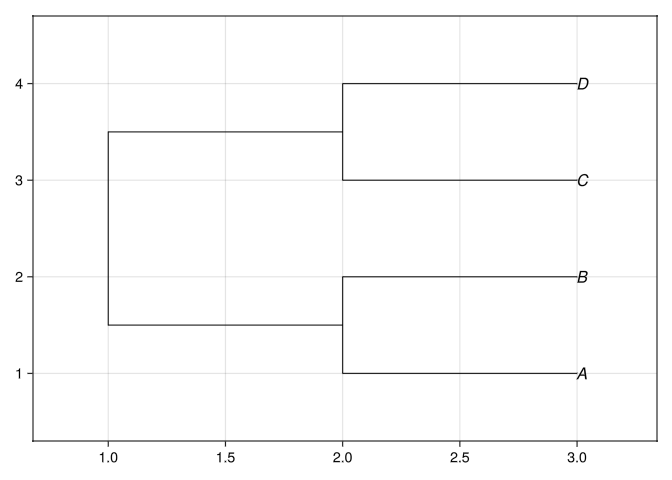

```julia
plot(phylogeny) # same as `phyloplot(phylogeny)`
```

This approach is useful when composing and exploring simple phylogenies by hand in a REPL workflow:

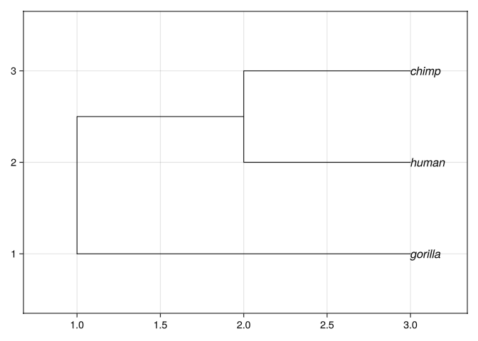

```julia
plot(newick"(human, (chimp, gorilla));")

plot(newick"(chimp, (human, gorilla));")

plot(newick"(gorilla, (human, chimp));")
```

### 2.2 A more general visualization pipeline

The full visualization pipeline, suitable for more general use, has 2 explicit steps:

1. Parse or read the phylogenetic data into a phylogenetic object.
2. Create a `Figure` and `Axis`, then draw the phylogeny into that axis.

Separating these steps lets the same plotting code work with phylogenies that were typed at the REPL, read from files, downloaded, simulated, or returned by an upstream analysis.

#### 2.2.1 Parsing one phylogeny from string content

We use `PhyloMakie.parsephylogeny` to convert a string containing exactly 1 phylogeny into a `PhyloMakie.LineageNetwork` object. The function takes a format specification as its first argument and the phylogenetic content as its second argument. Here, `NewickFormat()` says that the content follows the Newick format.

For this example, we define the tree string explicitly in code: we “hard code” the data. In practice, the string might instead come from a file, a URL, a database query, a simulation, or an upstream informatics pipeline.

```julia
bears1_str = "(Giant_Panda, (Andean_Bear, ((Asian_Black_Bear, (Sun_Bear, Sloth_Bear)), (American_Black_Bear, (Brown_Bear, Polar_Bear)))));"
```

```
"(Giant_Panda, (Andean_Bear, ((Asian_Black_Bear, (Sun_Bear, Sloth_Bear)), (American_Black_Bear, (Brown_Bear, Polar_Bear)))));"
```

```julia
bears1_phylogeny = parsephylogeny(NewickFormat(), bears1_str)
```

```
PhyloNetworks.HybridNetwork, Rooted Network
14 edges
15 nodes: 8 tips, 0 hybrid nodes, 7 internal tree nodes.
tip labels: Giant_Panda, Andean_Bear, Asian_Black_Bear, Sun_Bear, ...
(Giant_Panda,(Andean_Bear,((Asian_Black_Bear,(Sun_Bear,Sloth_Bear)),(American_Black_Bear,(Brown_Bear,Polar_Bear)))));
```

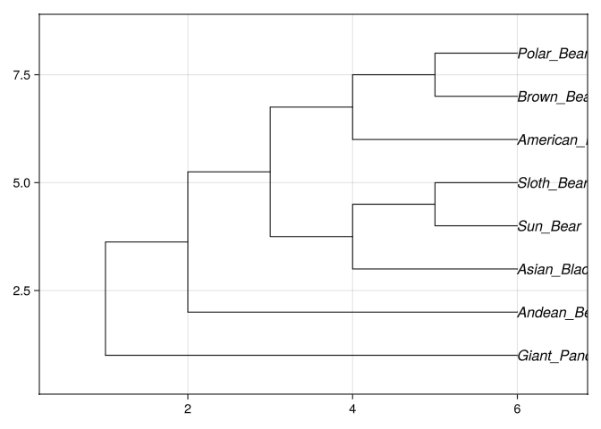

```julia
phyloplot(bears1_phylogeny)
```

#### 2.2.2 Parsing multiple phylogenies from string content

A data source can contain more than 1 phylogeny. In that case, we use `parsephylogenies`, which returns a *vector* of `LineageNetwork` objects. Here is a string containing 2 alternative bear phylogenies:

```julia
alternative_bear_trees_str = """
((Giant_Panda,Andean_Bear),(Brown_Bear,Polar_Bear));
(Giant_Panda,(Andean_Bear,(Brown_Bear,Polar_Bear)));
"""
```

```
"((Giant_Panda,Andean_Bear),(Brown_Bear,Polar_Bear));\n(Giant_Panda,(Andean_Bear,(Brown_Bear,Polar_Bear)));\n"
```

The plural parsing function preserves both phylogenies in a vector.

```julia
alternative_bear_phylogenies = parsephylogenies(
    NewickFormat(),
    alternative_bear_trees_str,
)
```

```
2-element Vector{PhyloNetworks.HybridNetwork}:
 PhyloNetworks.HybridNetwork, Rooted Network
6 edges
7 nodes: 4 tips, 0 hybrid nodes, 3 internal tree nodes.
tip labels: Giant_Panda, Andean_Bear, Brown_Bear, Polar_Bear
((Giant_Panda,Andean_Bear),(Brown_Bear,Polar_Bear));

 PhyloNetworks.HybridNetwork, Rooted Network
6 edges
7 nodes: 4 tips, 0 hybrid nodes, 3 internal tree nodes.
tip labels: Giant_Panda, Andean_Bear, Brown_Bear, Polar_Bear
(Giant_Panda,(Andean_Bear,(Brown_Bear,Polar_Bear)));
```

```julia
length(alternative_bear_phylogenies)
```

```
2
```

We can use the usual vector tools to select 1 phylogeny. `first` is a clear choice when we expect or need only the first result; indexing lets us choose any other result.

```julia
first_alternative = first(alternative_bear_phylogenies)
```

```
PhyloNetworks.HybridNetwork, Rooted Network
6 edges
7 nodes: 4 tips, 0 hybrid nodes, 3 internal tree nodes.
tip labels: Giant_Panda, Andean_Bear, Brown_Bear, Polar_Bear
((Giant_Panda,Andean_Bear),(Brown_Bear,Polar_Bear));
```

```julia
second_alternative = alternative_bear_phylogenies[2]
```

```
PhyloNetworks.HybridNetwork, Rooted Network
6 edges
7 nodes: 4 tips, 0 hybrid nodes, 3 internal tree nodes.
tip labels: Giant_Panda, Andean_Bear, Brown_Bear, Polar_Bear
(Giant_Panda,(Andean_Bear,(Brown_Bear,Polar_Bear)));
```

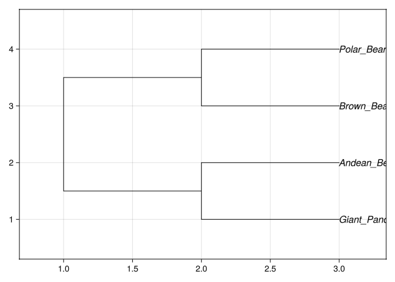

```julia
phyloplot(first_alternative)
```

#### 2.2.3 Creating and reading a Newick file

`parsephylogeny` and `parsephylogenies` treat a string as literal phylogenetic *content*. For a string that names a file on your computer, we instead use `readphylogeny` or `readphylogenies`.

Create that file now. Use the copy button on the following block, paste the text into a plain-text editor, and save it as `example-phylogenies.tre`. The file contains 3 short phylogenies, 1 per line.

```
((A:1,B:1)AB:2,(C:1,D:1)CD:2)root;
(A:1,(B:1,(C:1,D:1)CD:1)BCD:1)root;
((A:1,C:1)AC:2,(B:1,D:1)BD:2)root;
```

A reasonable default is your `Downloads` directory:

```julia
example_tree_path = joinpath(
    homedir(),
    "Downloads",
    "example-phylogenies.tre",
)
```

If you saved the file in a Julia learning project instead, use that path. For example, either of the following may match a directory that you created:

```julia
example_tree_path = joinpath(
    homedir(),
    "projects",
    "julia",
    "learning1",
    "data",
    "example-phylogenies.tre",
)

example_tree_path = joinpath(
    pwd(),
    "data",
    "example-phylogenies.tre",
)
```

Use the path to the location where *you* saved the file. Then confirm that Julia can find it before asking PhyloMakie to read it.

```julia
isfile(example_tree_path)
```

The file contains 3 phylogenies, so use the plural reader.

```julia
file_phylogenies = readphylogenies(
    NewickFormat(),
    example_tree_path,
)
```

```julia
length(file_phylogenies)
```

```julia
phyloplot(first(file_phylogenies); useedgelength = true)
```

If a file must contain exactly 1 phylogeny, use the singular `readphylogeny` function instead.

#### 2.2.4 Reading phylogenetic data from a URL

TreeBASE exposes published phylogenies through its web service. The following URL returns tree `Tr1453` directly in NEXUS format:

[Open or download TreeBASE tree Tr1453 as NEXUS](https://treebase.org/treebase-web/phylows/tree/TB2:Tr1453?format=nexus)

Julia’s standard-library `Downloads` module retrieves the response.

```julia
using Downloads
```

```julia
treebase_url = "https://treebase.org/treebase-web/phylows/tree/TB2:Tr1453?format=nexus"
```

```
"https://treebase.org/treebase-web/phylows/tree/TB2:Tr1453?format=nexus"
```

`Downloads.download` stores the response in a temporary file and returns its path. PhyloMakie’s NEXUS reader accepts a file path, so the download can feed directly into the reader without any repository checkout or bundled asset.

```julia
treebase_phylogenies = readphylogenies(
    NexusFormat(),
    Downloads.download(treebase_url),
)
```

```julia
length(treebase_phylogenies)
```

```julia
phyloplot(first(treebase_phylogenies))
```

The `length` call should return `1`. Because TreeBASE is a remote service, a slow response or network interruption can require running the download cell again.

The function names therefore encode 2 decisions:

| Data source | Exactly 1 phylogeny | Zero or more phylogenies |
| --- | --- | --- |
| String content or an open `IO` stream | `parsephylogeny` | `parsephylogenies` |
| File path | `readphylogeny` | `readphylogenies` |

In each case, the format object—for example, `NewickFormat()` or `NexusFormat()`—states how PhyloMakie should interpret the source.

#### 2.2.5 Composition with Makie: `Figure` and `Axis`

The convenience form `phyloplot(phylogeny)` creates a complete figure for us. For a figure that will contain titles, annotations, or additional panels, we create the Makie objects explicitly and use the mutating `phyloplot!` function to draw into an existing axis.

```julia
figure = Figure(size = (900, 460))
```

```julia
axis = Axis(figure[1, 1]; title = "An alternative bear phylogeny")
```

```
Makie.Axis with 0 plots:
```

```julia
hidedecorations!(axis)
hidespines!(axis)
```

```julia
tree_plot = phyloplot!(
    axis,
    first_alternative;
    useedgelength = false,
    showtiplabel = true,
    shownodelabel = true,
    tipoffset = 0.12,
)
```

```
Plot{phyloplot, Tuple{PhyloNetworks.HybridNetwork}}
```

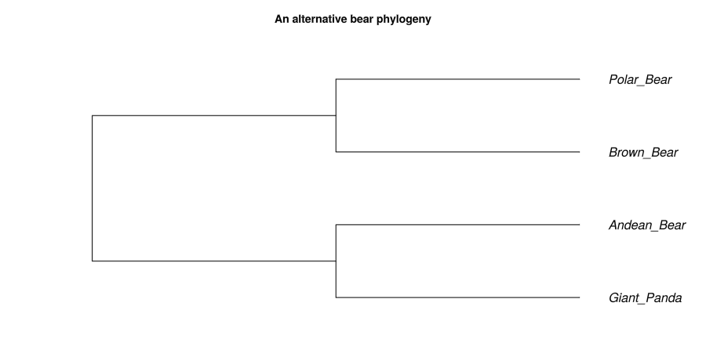

```julia
figure
```

Keeping a name for the returned plot object is useful. It lets later code inspect the positions calculated by PhyloMakie or update plot attributes without reconstructing the figure.

```julia
node_positions(tree_plot)
```

7×5 DataFrame

| Row | number Int64 | name String | isleaf Bool | x Float64 | y Float64 |
| --- | --- | --- | --- | --- | --- |
| 1 | 1 | Giant_Panda | true | 3.0 | 1.0 |
| 2 | 2 | Andean_Bear | true | 3.0 | 2.0 |
| 3 | -3 |  | false | 2.0 | 1.5 |
| 4 | 3 | Brown_Bear | true | 3.0 | 3.0 |
| 5 | 4 | Polar_Bear | true | 3.0 | 4.0 |
| 6 | -4 |  | false | 2.0 | 3.5 |
| 7 | -2 |  | false | 1.0 | 2.5 |

#### 2.2.6 Example: A bear phylogeny with PhyloPic silhouettes

Makie composition is not limited to labels and lines. The separate [PhyloPicMakie](https://github.com/jeetsukumaran/PhyloPicMakie.jl) package can query [PhyloPic](https://www.phylopic.org/) for organism silhouettes and add those images to an existing Makie axis.

**NoteAdditional package**

This final example also requires PhyloPicMakie. If it is not already in the active environment, run:

```julia
using Pkg

Pkg.add(url = "https://github.com/jeetsukumaran/PhyloPicMakie.jl")
```

Resolving taxon names and downloading uncached silhouettes require an internet connection.

```julia
using PhyloPicMakie: augment_phylopic!
```

PhyloPic resolves scientific names, so this phylogeny uses scientific names as its tip labels. Underscores keep the Newick labels portable; we will replace them with spaces before sending the names to PhyloPic.

```julia
selected_bears = newick"""
(
    Ailuropoda_melanoleuca:3,
    (
        Ursus_americanus:2,
        (Ursus_arctos:1,Ursus_maritimus:1):1
    ):1
);
"""
```

```
PhyloNetworks.HybridNetwork, Rooted Network
6 edges
7 nodes: 4 tips, 0 hybrid nodes, 3 internal tree nodes.
tip labels: Ailuropoda_melanoleuca, Ursus_americanus, Ursus_arctos, Ursus_maritimus
(Ailuropoda_melanoleuca:3.0,(Ursus_americanus:2.0,(Ursus_arctos:1.0,Ursus_maritimus:1.0):1.0):1.0);
```

```julia
bear_figure = Figure(size = (980, 600))
bear_axis = Axis(bear_figure[1, 1]; title = "Selected living bears")
hidedecorations!(bear_axis)
hidespines!(bear_axis)
```

We first draw only the branches. We retain the returned `PhyloPlot` so that we can ask for the tip coordinates that PhyloMakie calculated.

```julia
bear_tree_plot = phyloplot!(
    bear_axis,
    selected_bears;
    useedgelength = true,
    showtiplabel = false,
)
```

```
Plot{phyloplot, Tuple{PhyloNetworks.HybridNetwork}}
```

```julia
bear_tip_rows = [
    row for row in eachrow(node_positions(bear_tree_plot)) if row.isleaf
]
```

```
4-element Vector{DataFrames.DataFrameRow{DataFrames.DataFrame, DataFrames.Index}}:
 DataFrameRow
 Row │ number  name                    isleaf  x        y
     │ Int64   String                  Bool    Float64  Float64
─────┼──────────────────────────────────────────────────────────
   1 │      1  Ailuropoda_melanoleuca    true      4.0      1.0
 DataFrameRow
 Row │ number  name              isleaf  x        y
     │ Int64   String            Bool    Float64  Float64
─────┼────────────────────────────────────────────────────
   2 │      2  Ursus_americanus    true      4.0      2.0
 DataFrameRow
 Row │ number  name          isleaf  x        y
     │ Int64   String        Bool    Float64  Float64
─────┼────────────────────────────────────────────────
   3 │      3  Ursus_arctos    true      4.0      3.0
 DataFrameRow
 Row │ number  name             isleaf  x        y
     │ Int64   String           Bool    Float64  Float64
─────┼───────────────────────────────────────────────────
   4 │      4  Ursus_maritimus    true      4.0      4.0
```

```julia
bear_tip_positions = Point2f[
    Point2f(row.x, row.y) for row in bear_tip_rows
]
```

```
4-element Vector{Point{2, Float32}}:
 [4.0, 1.0]
 [4.0, 2.0]
 [4.0, 3.0]
 [4.0, 4.0]
```

```julia
bear_tip_taxa = replace.(
    String[row.name for row in bear_tip_rows],
    "_" => " ",
)
```

```
4-element Vector{String}:
 "Ailuropoda melanoleuca"
 "Ursus americanus"
 "Ursus arctos"
 "Ursus maritimus"
```

```julia
hcat(bear_tip_taxa, bear_tip_positions)
```

```
4×2 Matrix{Any}:
 "Ailuropoda melanoleuca"  Float32[4.0, 1.0]
 "Ursus americanus"        Float32[4.0, 2.0]
 "Ursus arctos"            Float32[4.0, 3.0]
 "Ursus maritimus"         Float32[4.0, 4.0]
```

We pass those coordinates and names to `augment_phylopic!`. The exclamation mark matters: this form adds the silhouettes to the `bear_axis` that already contains the phylogeny.

```julia
bear_glyph_plot = augment_phylopic!(
    bear_axis,
    first.(bear_tip_positions),
    last.(bear_tip_positions);
    taxon = bear_tip_taxa,
    image_rendering = :thumbnail,
    glyph_size = 0.27,
    placement = :left,
    xoffset = 0.18,
    on_missing = :error,
);
```

Finally, we use Makie’s `text!` function to place readable scientific names beyond the silhouettes. The tree, the silhouettes, and the text now share 1 axis and can be displayed or saved as 1 figure.

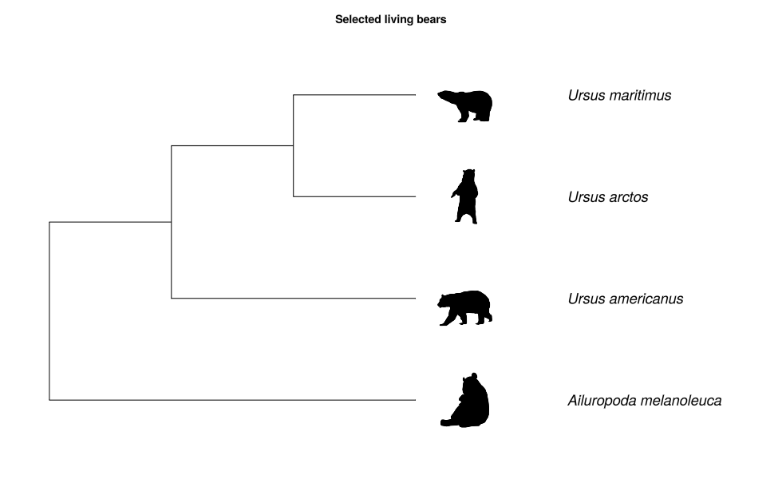

```julia
text!(
    bear_axis,
    first.(bear_tip_positions) .+ 1.25,
    last.(bear_tip_positions);
    text = bear_tip_taxa,
    align = (:left, :center),
    font = :italic,
    fontsize = 18,
)
xlims!(bear_axis, 0.7, 6.9)
ylims!(bear_axis, 0.35, 4.65)
bear_figure
```

**WarningPhyloPic image licenses**

Each PhyloPic image carries its own license and attribution metadata. Inspect and retain those terms before publishing or redistributing a figure that uses the image.

The complete workflow now has a repeatable structure: identify the source and format, parse or read the phylogeny, draw it into a Makie axis, and then use ordinary Makie functions or compatible packages to build the rest of the scientific graphic around it.

Back to top